# W1：課程說明與須知事項

心理教育統計 2026

授課教師：陳紹慶 | e-mail: csc2009@mail.tcu.edu.tw

2026/02/23

# 歡迎來到心理教育統計

## 統計學是什麼？

統計**不是**數學計算，而是——

> 在混亂的數據中，找到通往真相的地圖。

**核心問題**：

- 我們每天都在做判斷——但憑的是直覺還是證據？
- 「冰淇淋銷量越高，溺水人數越多」→ 吃冰淇淋會溺水嗎？
- 「考前拜拜的考試成績比較好」→ 拜拜能提高分數嗎？

## 直覺的陷阱

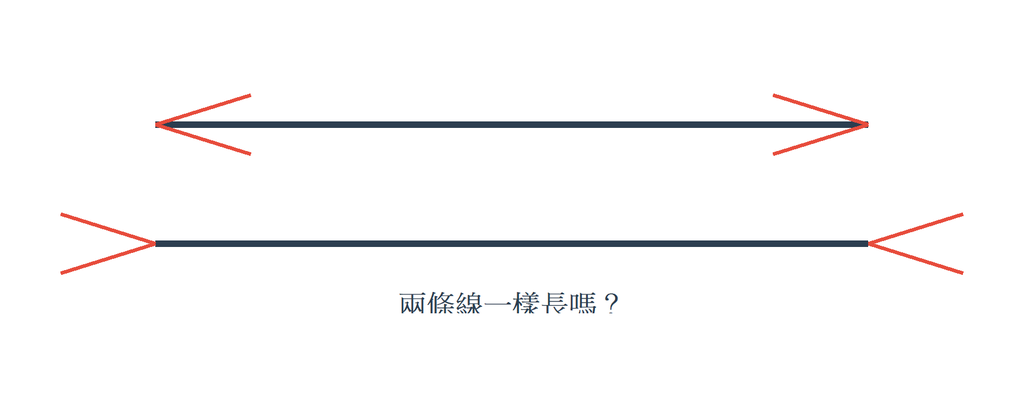

> 連眼睛都會被騙——所以我們需要統計工具來輔助判斷。

## 偽相關：數據會說謊

| 變項 A | 變項 B | 真正原因 |
| --- | --- | --- |
| 冰淇淋銷量 ↑ | 溺水人數 ↑ | **氣溫** 同時影響兩者 |
| 疫苗副作用致病個案數 ↑ | 自閉症確診數 ↑ | **環境條件改變** 的巧合 |

> 相關 ≠ 因果——這是本課程最重要的一句話。

**推薦網站**：[Spurious Correlations](https://www.tylervigen.com/spurious-correlations)

# 課程全貌預覽

## 學期四部曲

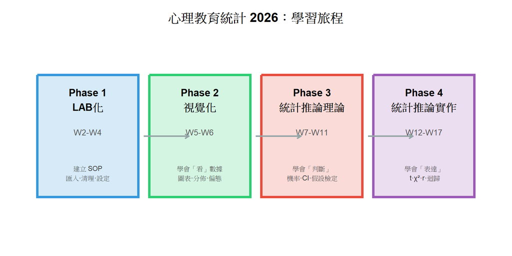

- 註：本學期只有4/6清明節放假一次

## 各階段內容

| 階段 | 週次 | 關鍵技能 | 里程碑 |
| --- | --- | --- | --- |
| **LAB化** | W2-W4 | 匯入·變項設定·資料清理 | 熟悉LAB流程 |
| **視覺化** | W5-W6 | 描述統計·圖表·偏態 | 能用圖表說故事 |
| **理論** | W7-W11 | 常態條件·CLT·CI·假設檢定 | 理解 p 值的意義 |
| **推論** | W12-W17 | t 檢定·卡方·相關·迴歸 | 獨立完成分析報告 |

> W7-W11 是最抽象的「大魔王」區段——別擔心，我們會使用擬工具來幫助理解。

## 各週次課程學習程序

- 除W1(今日)、W11,W16,W17，各週皆為2小時講授示範，以及1小時LAB實作。全程於電腦教室進行。
- W11是期中LAB，一小時說明及2小時實作。
- W16是本學期學習內容總複習，以及期末LAB說明。
- W17是期末LAB，3小時實作。
- LAB實作檔案領域取繳交方式，於W2~W4說明及演練。

## 對應教材

- 《用 jamovi 上手統計學》（免費線上電子書）
  - [中文版](https://scgeeker.github.io/lsj-book-zh_tw/)
  - 英文原版 PDF
- [jamovi 社群資源](https://www.jamovi.org/community.html)

> 本課程所有[教學簡報](https://scgeeker.github.io/lsj_2026_lecture_slides/)都附上對應的電子書章節連結，以及該週LAB作業說明。

# 為什麼選 jamovi？

## jamovi 的特色

**對學生友善**：

- 免費、開源
- 圖形介面，不需寫程式
- 即時顯示分析結果
- 內建學習資料集

**對教學友善**：

- .omv 檔案記錄完整操作歷程
- 分析可再現（Reproducibility）
- 跨平台（Windows/Mac/Linux/雲端）
- R 語言為底層引擎

## 分析即存檔

**jamovi 的核心概念**：

```
打開 CSV → 設定變項 → 執行分析 → 全部存在一個 .omv 檔案裡
```

- 不像 Excel——分析結果不會「消失」
- 不像 SPSS——不需要額外的語法檔
- **一個 .omv = 你的完整分析日記**

> AI 評量系統會讀取你的 .omv 檔案，確認你的每一步操作。

# 安裝 jamovi

## 方式一：桌面版安裝（推薦）

**下載網址**：https://www.jamovi.org/download.html

| 平台 | 安裝方式 |
| --- | --- |
| **Windows** | 下載 `.exe` 安裝檔 → 雙擊安裝 |
| **macOS** | 下載 `.dmg` → 拖曳至 Applications |
| **Linux** | `flatpak install flathub org.jamovi.jamovi` |
| **ChromeOS** | 啟用 Linux (Crostini) → 同 Linux 安裝 |

**版本選擇**：

- **solid（穩定版）**：2.6.x — 適合作業繳交
- **current（最新版）**：2.7.x — 新增 Plots Tab 等功能

> 建議安裝 **2.7.x**，確保與課程教材一致。

## 方式二：jamovi Cloud（免安裝）

**網址**：https://cloud.jamovi.org

**優點**：

- Chrome瀏覽器直接使用
- 支援各式可使用Chrome瀏覽器的平板
- 不佔硬碟空間
- 永遠是最新版本

**方案**：

| 方案 | 費用 |
| --- | --- |
| Guest | 免費（有限制） |
| Priority | 新台幣205元/月 |
| Team | 教育用團體訂閱 |

- 團體訂閱登記見簡報末頁

**注意**：Cloud 版適合無法安裝軟體的同學，但**建議以桌面版為主**。

## 桌面版 vs 雲端版

| 比較項目 | 桌面版 | 雲端版 |
| --- | --- | --- |
| 安裝 | 需下載安裝 | 瀏覽器開啟 |
| 離線使用 | ✓ | ✗ |
| 資料存放 | 本機 | 伺服器（用後刪除） |
| 版本 | 自行選擇 | 永遠最新 |
| 適用裝置 | 電腦 | 任何有瀏覽器的裝置 |
| **課程建議** | **主要使用** | 只能在電腦教室操作 只有自用平板 |

## 安裝 lsj-data 模組

安裝完 jamovi 後，請安裝教科書資料模組(Cloud版已安裝)：

**步驟**：

1. 開啟 jamovi
2. 點擊右上角 **「+」** 圖示（Modules）
3. 選擇 **jamovi library**
4. 切換到 **Available** 頁籤
5. 找到 **lsj-data** → 點擊 **INSTALL**

**驗證安裝成功**：

- 左上角 ☰ → **Open** → **Data Library**
- 應出現 **learning statistics with jamovi** 資料夾
- 裡面包含 `booksales`、`clinicaltrial` 等教學資料集

> 下週（W2）會用到 `booksales` 資料，請確認安裝成功。

# 課程評量制度

## 課程規範與學習成效評估1/2

- LAB作業繳交與補強
  - 每週LAB結束前繳交
  - 二日內收到個人初評報告：程式檢查+人工批閱
  - 下週上課前繳交改善版本（含**當週缺課補交**，缺課補交以初評結果紀錄)
  - 課後加強輔導預計於W4開始，安排於當週課程宣佈
  - 當週無法出席電腦教室LAB，需於事前通知要採用的補課方案（見本節最後）。

## 課程規範與學習成效評估2/2

- 期中與期末LAB綜合評量
  - 當週LAB結束前完成。W11於W12上課前通知初評結果，W17於學期成績送出時同時通知綜合評估結果。
  - W11,W17**缺席者**不予補交。
  - 兩次LAB使用相同資料，測試題目於LAB前說明。

## LAB作業雙檔案制度

**1. jamovi 分析檔**

`學號_姓名_W##_Lab.omv`

- 記錄你的**操作過程**
- AI 會檢查：
  - 變項類型是否正確
  - 是否使用 Filter
  - 分析設定是否完整

**2. Word 分析報告**

`學號_姓名_W##_Report.docx`

- 記錄你的**思考過程**
- 教師會評閱：
  - 操作步驟說明
  - 分析結果呈現
  - 思辨問題回答

## 評量配分

| 評分項目 | 配分 | 說明 | 評比方式 |
| --- | --- | --- | --- |
| 格式與命名 | 15% | 檔名正確、結構完整 | 自動 |
| 分析結果呈現 | 25% | 正確貼上 jamovi 輸出表格 | 自動 |
| 操作紀錄 / 修正說明 | 30% | 記錄操作步驟與判斷理由 | 手動 |
| 思辨問題回答 | 30% | 展現對統計概念的理解 | 手動 |

- 此表配分比例為基本參考，各週作業配分比例依實作內容安排調整

## 補課方案

1. 線上同步：可同時進行學習及實作，於該週LAB完成作業，並收到初評報告。
2. 無法參與：於補交時限前繳交LAB作業，以初評結果紀錄。
- 每週上課有網路直播錄影，可隨時回放觀看。

```
缺課告知信作標題內容示範

title: W__無法上課 學生 XYZ

由於（   ），本週無法至電腦教室上課。可以線上同步上課／無法參與同步上課。
```

## 回饋與修正機制

```
繳交 → AI 評量 → 個人回饋報告 → 修正重繳 → 最終成績
```

1. **繳交**：每週LAB實作結束前，上傳至 Google Classroom
2. **評量**：2 天內*雲端資料夾*取得個人化回饋報告( HTML 格式)
3. **修正**：依據回饋改進，下次上課前重新繳交(W4後安排輔導課)
4. **最終成績**：整合初次與修正成績（缺課補交者只有初次成績)

## 注意事項

> 除 W11期中與W17 期末外，每週都有**修正機會**——重點是學會，不是一次做到完美。 期中預警：評估W11以前的LAB作業繳交及修正狀況。

# 檔案命名規範

## 命名格式（非常重要！）

```
學號_姓名_W##_Lab.omv
學號_姓名_W##_Report.docx
```

**正確範例**：

- `113516001_王小明_W2_Lab.omv` ✓
- `113516001_王小明_W2_Report.docx` ✓

**錯誤範例**：

- `王小明作業.omv` ✗（缺學號、週次）
- `113516001 王小明 W2 Lab.omv` ✗（使用空格）
- `W2_Lab.omv` ✗（缺學號姓名）

## 重要提醒!

> AI 程式系統只依靠檔名識別你是誰。**格式錯誤 = 直接扣分。**

## 數據完整性規範

**原始數據是神聖不可侵犯的。**

- ❌ 在 Excel 中手動刪改數據後才匯入
- ❌ 直接刪除 jamovi 試算表中的列
- ❌ 在 Word 中手動修改統計數值
- ✅ 使用 jamovi 的 **Filters** 排除異常值
- ✅ 使用 **Compute** 建立新變項
- ✅ 所有修改留下操作紀錄

> AI程式會掃描你的 .omv 檔案，確認操作的合規性。

# APA 寫作標準預覽

## 統計結果的標準寫法1/2

本學期會逐步學習 **APA 格式**的統計報告寫法：

**範例**：

> 獨立樣本 t 檢定顯示，實驗組的焦慮分數顯著低於控制組，*t*(24) = -2.56, *p* = .017, *d* = -0.50。

## 統計結果的標準寫法2/2

**格式要點**：

| 元素 | 規則 | 範例 |
| --- | --- | --- |
| 統計符號 | 斜體 | *t*, *p*, *r*, *F* |
| p 值 | 小數點前不加 0 | *p* = .017（非 0.017） |
| 效果量 | 必須報告 | *d* = -0.50 |

> 不用現在記住——每週作業都會練習。

# 實作示範

## Hello World：第一次開啟 jamovi

**請跟著做**：

1. 開啟 jamovi（桌面版或雲端版）
2. 觀察介面：
   - 左側 = 資料表（Data）
   - 右側 = 分析結果（Results）
   - 上方 = 分析選單（Analyses）
3. 左上角 ☰ → **Open** → **Data Library**
4. 選擇 **learning statistics with jamovi** → **booksales**
5. 觀察三個變項：Month、Days、Sales

## 第一次存檔

**步驟**：

1. 左上角 ☰ → **Save As**
2. 選擇存檔位置（建議建立專用資料夾）
3. 檔名輸入：`你的學號_你的姓名_W1_Lab.omv`
4. 點擊儲存

## **檢核清單**

- jamovi 已安裝（或可開啟 Cloud 版）
- lsj-data 模組已安裝
- 成功開啟 booksales 資料集
- 檔案已儲存且命名正確

# 小結與展望

## 下週預告

**W2：與 jamovi 的第一次接觸**

- 匯入 CSV 檔案
- 認識測量尺度（Nominal / Ordinal / Continuous）
- 設定變項類型與標籤
- 建立計算變項（Compute）

**請先完成**：

1. 安裝 jamovi 或訂閱jamovi雲端版

## 課程資源

| 資源 | 連結 |
| --- | --- |
| 中文電子書 | [用 jamovi 上手統計學](https://scgeeker.github.io/lsj-book-zh_tw/) |
| jamovi 下載 | [jamovi.org/download](https://www.jamovi.org/download.html) |
| jamovi Cloud | cloud.jamovi.org |
| 訂閱報名 | [表單](https://forms.gle/UPFJNK6nnBYsxdgr5) |
| Google Classroom | 課程代碼：`edhbksfw` |